# How Did People with Different Occupations and Income Levels Vote?

## 4.2 Variable “Voter Particitaion”

*VCF0703* is the variable that can easily tell what percentage of respondents registered and voted and what percentage did not. It has three classes: 1. Not registered, and did not vote 2. Registered, but did not vote 3. Voted(registered)

followed is the graph shows the number of respondents in each class

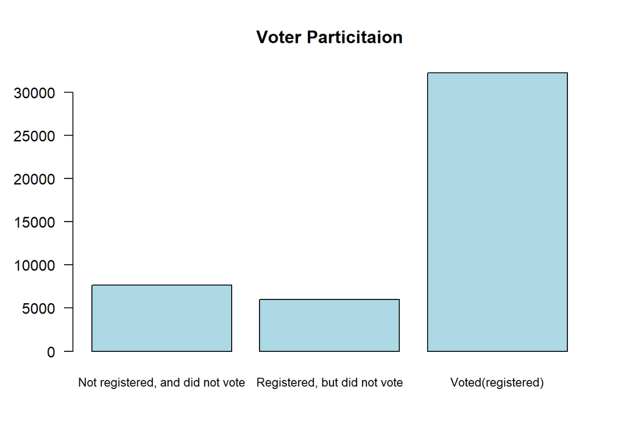

```r
vote_turnout = c("Not registered, and did not vote",
            "Registered, but did not vote",
            "Voted(registered)")
barplot(table(anes_dat$VCF0703), names = vote_turnout,
        las=1,
        col = "lightblue",
        cex.names=0.8,
        main="Voter Particitaion")
```

## 4.3 Variable “Occupation Group”

*VCF0115* is the variable that reveals respondents’ occupations, it has six classes: 1. Professional and managerial 2. Clerical and sales workers 3. Skilled, semi-skilled and service workers 4. Laborers, except farm 5. Farmers, farm managers, farm laborers and foremen; forestry and fishermen 6. Homemakers

followed is the graph shows the number of respondents in each class

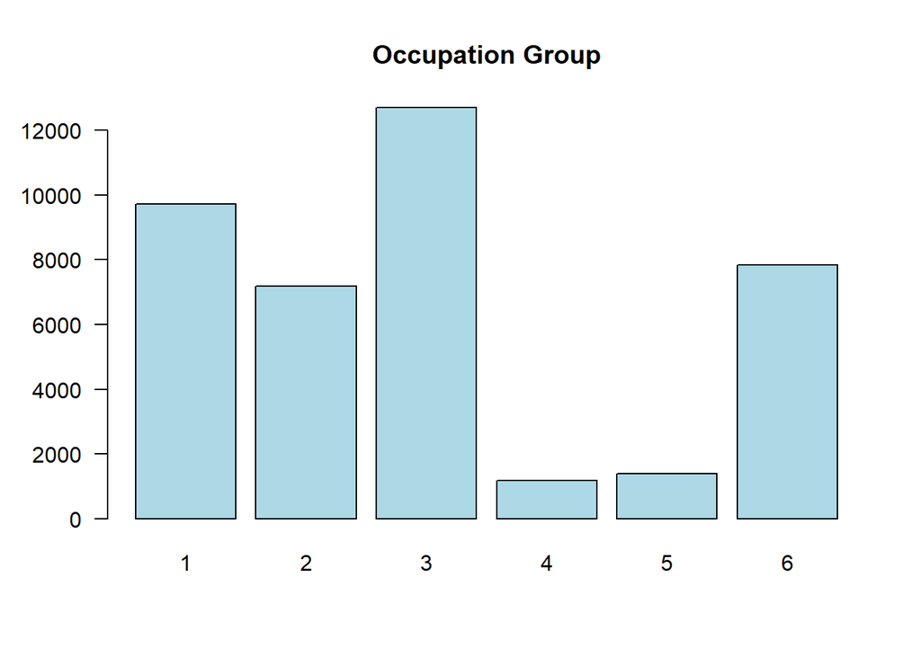

```r
barplot(table(anes_dat$VCF0115),
        las=1,
        col = "lightblue",
        main="Occupation Group")
```

## 4.4 Variable “Vote”

*VCF0706* is the variable that reveals respondents’ choices of presidential vote and nonvote, it has five classes: 1. Democrat 2. Republican 3. Major third party candidate 4. Other 7. Did not vote or voted but not for president

followed is the graph shows the number of respondents in each class

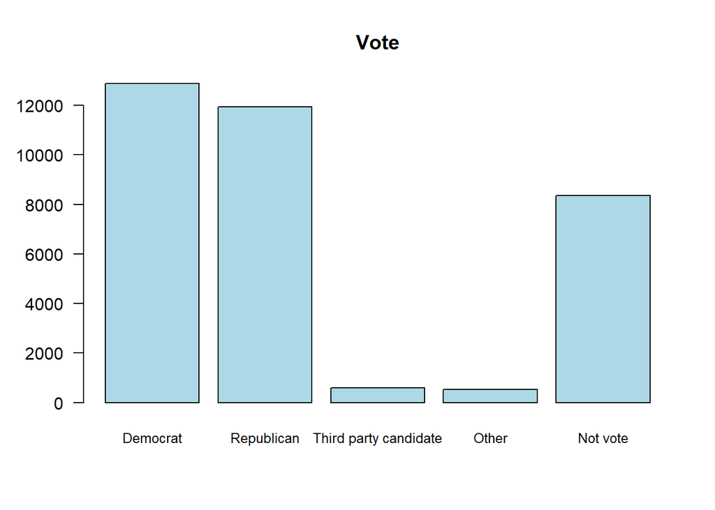

```r
vote_choice = c("Democrat",
                "Republican",
                "Third party candidate",
                "Other",
                "Not vote")
barplot(table(anes_dat$VCF0706), names = vote_choice,
        las=1,
        col = "lightblue",
        cex.names=0.8,
        main="Vote")
```

# 5. Data processing

## 5.1 Process variables for analysis

First, I selected five variables for further analysis and filtered data was saved to the `output` folder.

```r
Presidential_Election_Year = as.character(seq(1952, 2016, 4))

ANES_data = anes_dat%>%
  mutate(
    year = as_factor(VCF0004),
    income = as_factor(VCF0114),
    turnout = as_factor(VCF0703),
    occupation = as_factor(VCF0115),
    vote=as_factor(VCF0706)
  )%>%
  filter(year %in% Presidential_Election_Year)

library(data.table)

data.table(ANES_data%>%
             select(year, income, turnout, occupation, vote)%>%
             filter(!is.na(turnout))%>%
             sample_n(20))
```

```
##     year                  income                             turnout
##  1: 1984  3. 34 to 67 percentile               3. Voted (registered)
##  2: 2012  3. 34 to 67 percentile               3. Voted (registered)
##  3: 2012  3. 34 to 67 percentile     2. Registered, but did not vote
##  4: 1972  3. 34 to 67 percentile               3. Voted (registered)
##  5: 2016  3. 34 to 67 percentile               3. Voted (registered)
##  6: 1996  3. 34 to 67 percentile     2. Registered, but did not vote
##  7: 1980                    <NA>               3. Voted (registered)
##  8: 1992 5. 96 to 100 percentile 1. Not registered, and did not vote
##  9: 1980  3. 34 to 67 percentile               3. Voted (registered)
## 10: 1992  2. 17 to 33 percentile               3. Voted (registered)
## 11: 2016  3. 34 to 67 percentile               3. Voted (registered)
## 12: 1960  3. 34 to 67 percentile               3. Voted (registered)
## 13: 2012  4. 68 to 95 percentile               3. Voted (registered)
## 14: 1992  2. 17 to 33 percentile 1. Not registered, and did not vote
```

[output cut: 48 more lines]

```r
ANES_data = ANES_data%>%select(year, income, turnout, occupation, vote)

save(ANES_data, file="C:/Users/Charlie/Documents/GitHub/Fall2020-Project1-charliechen1995/output/data_use.RData")
```

## 5.2 Answer the Question: Which income level group participate more in voting? high income or low income?

Which group tends to participate more in voting? I might guess home income group, is that true, let’s find out:

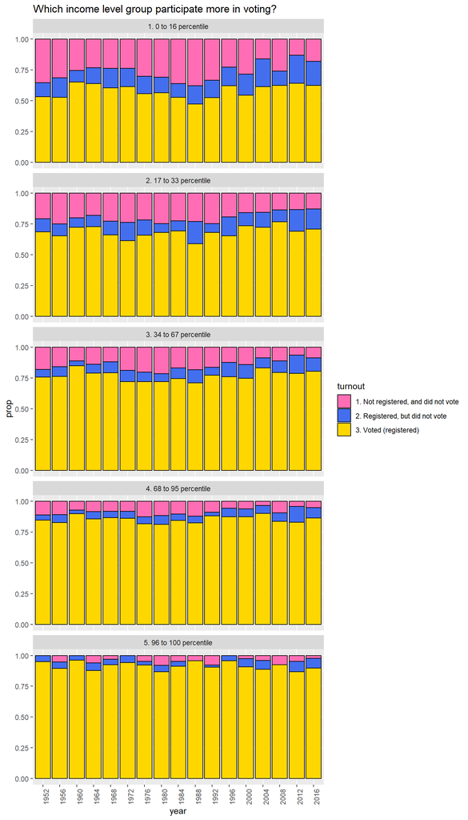

```r
anes_income_turnout_year = ANES_data %>%
  filter(!is.na(income) & !is.na(turnout))%>%
  group_by(year,income)%>%
  count(turnout)%>%
  group_by(year, income)%>%
  mutate(
    prop = n/sum(n)
  )

ggplot(anes_income_turnout_year,
       aes(x=year, y=prop, fill = turnout)) +
  geom_bar(stat="identity", colour="black")+
  scale_fill_manual(values=c("hotpink1", "royalblue2", "gold1"))+
  facet_wrap(~income, ncol=1) +
  theme(axis.text.x = element_text(angle = 90))+
  labs(title="Which income level group participate more in voting?")
```

## 5.3 Answer the Question: Are there any party perferances between high income level people and low income people?

I really want to know that did rich people and poor people vote for the same party or not? Are there any party perferances between high income level people and low income people? Let’s see the result:

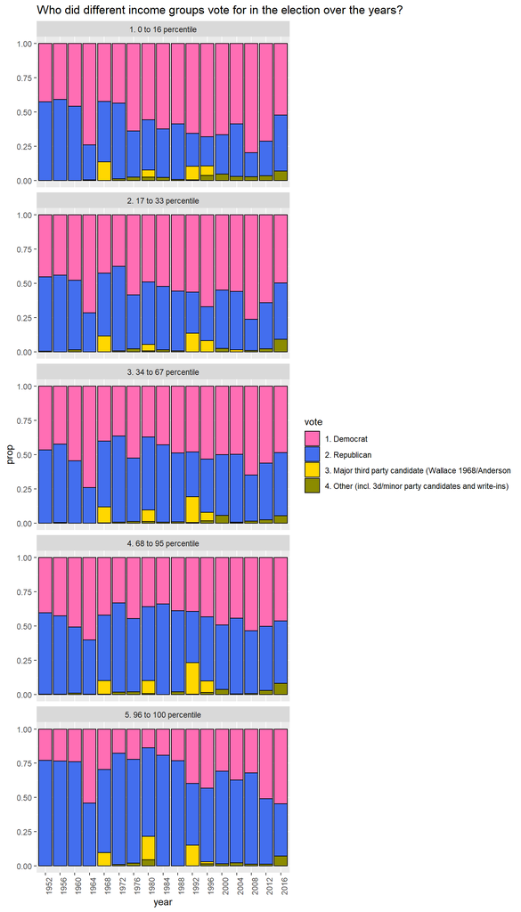

```r
anes_vote_income_year = ANES_data %>%
  filter(!is.na(income) & !is.na(vote))%>%
  filter(vote!="7. Did not vote or voted but not for president (exc.1972)")%>%
  group_by(year,income)%>%
  count(vote)%>%
  group_by(year, income)%>%
  mutate(
    prop=n/sum(n)
  )
#%>%
#  filter(vote == "1. Democrat" | vote == "2. Republican")

ggplot(anes_vote_income_year,
       aes(x=year, y=prop, fill=vote)) +
  geom_bar(stat="identity", colour="black")+
  scale_fill_manual(values=c("hotpink1", "royalblue2", "gold1", "yellow4"))+
  facet_wrap(~income, ncol=1) +
  theme(axis.text.x = element_text(angle = 90))+
  labs(title="Who did different income groups vote for in the election over the years?")
```

As we can see from the plots, lowest income level group (0 to 16 percentile) and the second lowest income level group (17 to 33 percentile) were more likely to vote for Democrat Party. However, High income level respondents (96 to 100 percentile) voted for Republican Party more. Respondents with middle income levels did not have outstanding perferances.

## 5.4 Answer the Question: Does certain occupation type prefer to vote for a particular party?

Since we already know that different income level groups behave quite differently in voting, what about different occupations? Does certain occupation type prefer to vote for a particular party? First, I want to know whether occupations are associated with different income levels. There are several plots shows the result:

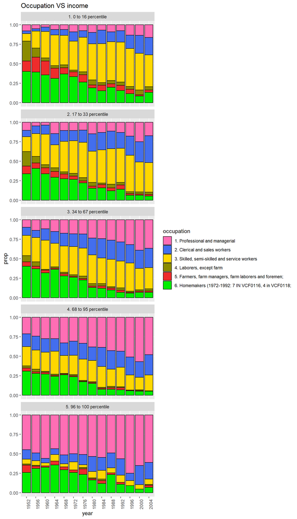

```r
anes_occupation_income_year = ANES_data %>%
  filter(!is.na(income) & !is.na(occupation))%>%
  group_by(year,income)%>%
  count(occupation)%>%
  group_by(year, income)%>%
  mutate(
    prop=n/sum(n)
  )

ggplot(anes_occupation_income_year,
       aes(x=year, y=prop, fill=occupation)) +
  geom_bar(stat="identity", colour="black")+
  scale_fill_manual(values=c("hotpink1", "royalblue2", "gold1", "yellow4", "firebrick2", "green2"))+
  facet_wrap(~income, ncol=1) +
  theme(axis.text.x = element_text(angle = 90))+
  labs(title="Occupation VS income")
```

We can see from the result that large proportion of highest income group (96 to 100 percentile) is Professional and managerial, however there is only small proportion in lowest income group (0 to 16 percentile). As income increases, proportion of categoria 1 (Professional and managerial) goes up. We can also see that large proportion of lowest income group (0 to 16 percentile) is categoria 3 (Skilled, semi-skilled and service workers), however there is only small proportion in highest income group (96 to 100 percentile). As income increases, proportion of categoria 3 (Skilled, semi-skilled and service workers) goes down.

Now, let’s take a look what’s the relationship between occupation groups and party perferances:

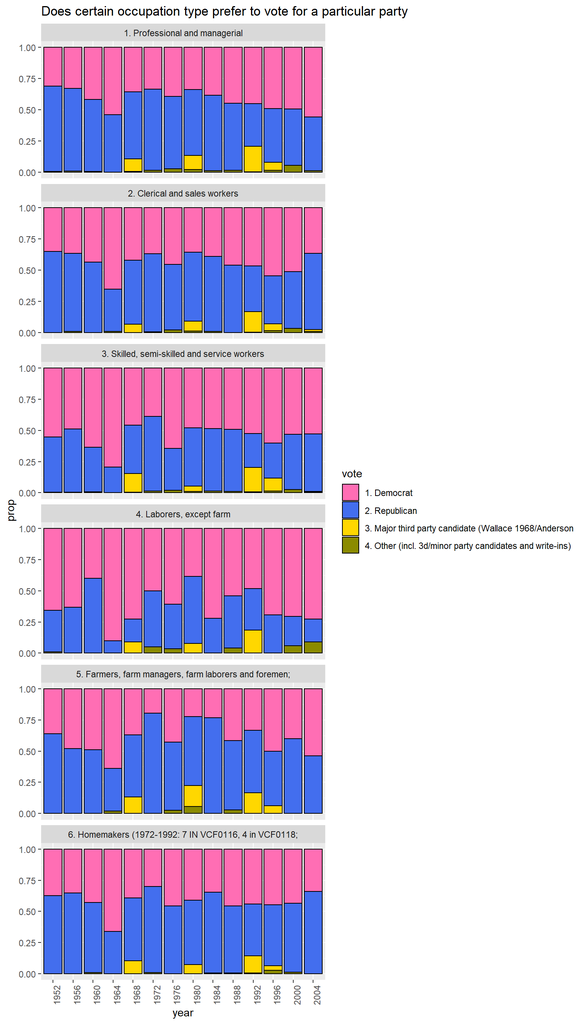

```r
anes_occupation_vote_year = ANES_data %>%
  filter(!is.na(occupation) & !is.na(vote))%>%
  filter(vote!="7. Did not vote or voted but not for president (exc.1972)")%>%
  group_by(year,occupation)%>%
  count(vote)%>%
  group_by(year, occupation)%>%
  mutate(
    prop=n/sum(n)
  )
#%>%
#  filter(vote == "1. Democrat" | vote == "2. Republican")

ggplot(anes_occupation_vote_year,
       aes(x=year, y=prop, fill=vote)) +
  geom_bar(stat="identity", colour="black")+
  scale_fill_manual(values=c("hotpink1", "royalblue2", "gold1", "yellow4"))+
  facet_wrap(~occupation, ncol=1) +
  theme(axis.text.x = element_text(angle = 90))+
  labs(title="Does certain occupation type prefer to vote for a particular party")
```

We can see that categorial 3 (skilled, semi_skilled and service workers) and categorial 4 (laborers, except farmers) have clearly preferance on Democrat Party. Categorial 2 (clerical and sales workers), categorial 5 (farmers, farm managers, farm laboers and foremen), categorial 6 (homemakers) tend to vote for Republic Party more. Categorial 1 (Professional and managerial) tends to vote for Republican Party more before 1988, but after that, they prefer Democrat more and more.

# 6. Conclusion

1. High income groups participated more in voting while low income groups participated less in voting.
2. Lowest income level group (0 to 16 percentile) and the second lowest income level group (17 to 33 percentile) were more likely to vote for Democrat Party. High income level respondents (96 to 100 percentile) voted for Republican Party more. Respondents with middle income levels did not have outstanding perferances.
3. Categorial 3 (skilled, semi_skilled and service workers) and categorial 4 (laborers, except farmers) had clearly preferance on Democrat Party. Categorial 2 (clerical and sales workers), categorial 5 (farmers, farm managers, farm laboers and foremen), categorial 6 (homemakers) preferred to vote for Republic Party. Categorial 1 (Professional and managerial) liked to vote for Republican Party more before 1988, but after 1988, they preferred Democrat more and more.